# Data Science Salary Analysis

Nicholas Nagy

2023-04-04

### Dataset Description:

The dataset that was used in this project contains data science job salaries. The data is originally from [ai-jobs](https://ai-jobs.net/salaries/form/) in collaboration with Ruchi Bhatia, a graduate student at Carnegie Mellon University (Bhatia, 2022). The dataset holds a collection of data science jobs with other attributes of the job. These attributes include company size, company location, the employee’s place of residence, the ratio of remote workers compared to office workers, along with information about the salary, type of employment, experience of employee, and finally the year the salary was paid.

#### More Details About the dataset:

Going into more specifics about the dataset, we can see that there are four employment types: part-time (PT), full-time (FT), contract (CT), and finally freelance (FL). In addition, employee experience is measured in 4 levels shown below.

- EN: Entry-level / Junior
- MI: Mid-level / Intermediate
- SE: Senior-level / Expert
- EX: Executive-level / Director

The possible two letter entries in the employee experience data column are shown above with exact definitions for each.

Furthermore, the salary can be represented in different currencies, but luckily we are also given the currency it is represented in, with the conversion to US dollars during the year the salary was paid. This was done by simply using the foreign exchange rate and dividing it by avg. USD rate for the respective year.

The residence of the employee and company for that working year is represented as an ISO 3166 country code. Also something to note, the remote ratio has three binned categories and definitions for each will be displayed below.

- 0: less than 20% remote workers at the company
- 50: greater than 20% but less than 80% remote workers at the company
- 100: greater than 80% remote workers at the company

Finally, the company size is represented with three binned categories which will be explained below.

- S: less than 50 employees
- M: 50 to 250 employees
- L: larger than 250 employees

### Dataset Questions:

1. (To fellow classmates pursuing a minor in the field) If you were planning on going into the field of data science, what is the estimated salary?
2. (To people currently working at a company doing data science) Does a larger company pay more? What company size would be best to look for a better salary?
3. (To everyone) How does location correlate with someone’s salary? Does remote work correlate with it also?

### Packages Used:

```r
library(tidyverse)
library(ggridges)
library(ggplot2)
library(gghalves)
library(RColorBrewer)
library(here)
library(readr)
library(patchwork)
library(gifski)
library(transformr)
library(gganimate)
library(devtools)
library(colorblindr)
```

### Data:

```r
ds_salary_data <- read.csv("data/ds_salaries.csv")
```

### Plot 1:

#### If you were planning on going into the data science field, what is the estimated salary?

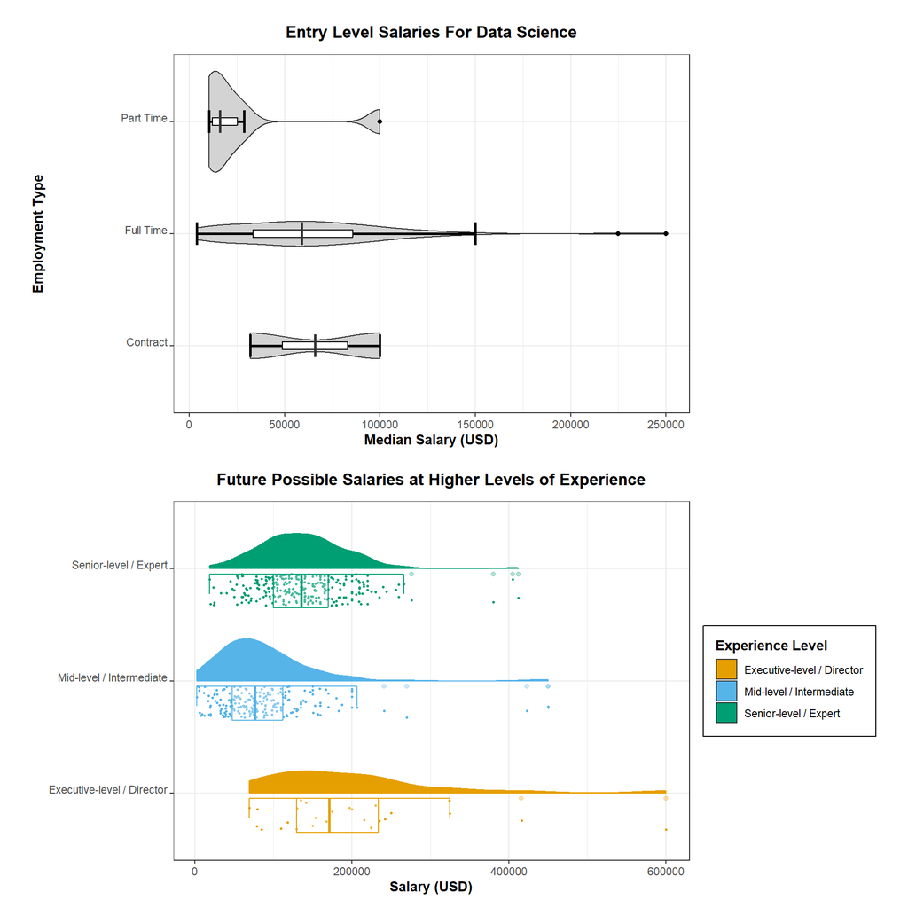

```r
options(scipen=10000)
plot1 <- ds_salary_data %>%
  mutate(exp_level = ifelse(experience_level == "EN","Entry-level / Junior",ifelse(experience_level == "MI", "Mid-level / Intermediate",ifelse(experience_level == "SE", "Senior-level / Expert", "Executive-level / Director")))) %>%
  filter(experience_level != "EN") %>%
  ggplot(aes(x = exp_level, y = salary_in_usd, colour = exp_level )) +
  geom_half_point(side = "l", size = 0.6) +
  geom_half_boxplot(side = "l", width = 0.7,
  alpha = 0.3, nudge = 0.05) +
  geom_half_violin(aes(fill = exp_level), side = "r") +
  guides(colour = "none")+
  coord_flip()+
  theme_bw() +
  labs(
    title = "Future Possible Salaries at Higher Levels of Experience",
    y = "Salary (USD)",
    x = "",
    fill = "Experience Level"
  ) +
  scale_fill_OkabeIto() +
  scale_colour_OkabeIto() +
  theme(
    plot.title = element_text(hjust = 0.5, face = "bold", vjust = 3),
    axis.text.y = element_text(vjust = 0),
    axis.title = element_text(face = "bold"),
    legend.title = element_text(face = "bold"),
    legend.background = element_rect(colour = "black"),
    legend.margin = margin(10,10,10,10),
    plot.caption = element_text(hjust = 0.5, face = "bold", vjust = 3)
  )

median_emp_type <- ds_salary_data %>%
  group_by(employment_type) %>%
  filter(experience_level == "EN") %>%
  summarize(salary_in_usd_median = median(salary_in_usd), sd = sd(salary_in_usd), len = length(salary_in_usd)) %>%
  mutate(se = sd / sqrt(len)) %>%
  mutate(CI99 = 2.576*se) %>%
  mutate(emp_type = ifelse(employment_type == "FT","Full Time",ifelse(employment_type == "PT", "Part Time","Contract")))

emp_type <- ds_salary_data %>%
  group_by(employment_type) %>%
  filter(experience_level == "EN")

write.csv(median_emp_type, file = "output/median_emp_type.csv")
write.csv(emp_type, file = "output/emp_type.csv")

plot2 <- emp_type %>%
  mutate(emp_type = ifelse(employment_type == "FT","Full Time",ifelse(employment_type == "PT", "Part Time","Contract"))) %>%
    ggplot(aes(x= emp_type, y = salary_in_usd)) +
    geom_violin(fill = "lightgrey") +
    stat_boxplot(geom = "errorbar", linewidth = 1, width = 0.2) +
    geom_boxplot(colour = "black", width = 0.07, linewidth = 0.5) +
  geom_boxplot(data = median_emp_type, aes(x = emp_type, y = salary_in_usd_median), width = 0.2) +
  coord_flip()+
  theme_bw() +
  labs(
    title = "Entry Level Salaries For Data Science",
    y = "Median Salary (USD)",
    x = "Employment Type"
  ) +
  theme(
    plot.title = element_text(hjust = 0.5, face = "bold", vjust = 3),
    axis.text.y = element_text(vjust = 0),
    axis.title = element_text(face = "bold"),
    plot.caption = element_text(hjust = 0.5, face = "bold", vjust = 3),
    plot.margin = margin(20,20,20,20)
  )

ggsave("figs/plot1_2.png", plot = plot1)
ggsave("figs/plot1_1.png", plot = plot2)

plot2 / plot1
```

This plot was created by using the data science salary data provided by Kaggle (Bhatia, 2022). Data wrangling methods were used to find the median for each of these categories, in which I used tidyverse (Wickham et al., 2019). This plot contains two plots merged together using the patchwork package (Pedersen, 2022a). The plots themselves were created using the ggplot2 package, and the first plot shown above uses both a violin plot and a box plot to display the data included in the package (Wickham, 2016). The first plot also has some theme modifications which would improve viewability, like changing how the text is formatted on the plot, and because this plot doesn’t use colour no other packages were used. In addition, there are no entry level freelance jobs included in this dataset therefore it was omitted from the first plot. For the second plot I started to use the package gghalves which allows you plot multiple plot types on the same plot; this allowed me to merge a violin plot, box plot and scatter plot (Tiedemann, 2022). This is also known as a raincloud plot and it is very effective at displaying distributions and uncertainty. Colour was used in this plot to help distinguish the three categories and the scale that was used is called OkabeIto; originally from colorblindr package (McWhite & Wilke, 2023). I used this scale because I know it works very well for different types of colour blind conditions. Finally for both plots I modified the variable fields to allow for easier understandability, like changing abbreviations to full words. Text formatting in the second plot was improved and the y axis label was removed because it was not required to send the message. Everything else changed in the second plot was for formatting text and labels correctly to make it easier to read. The target audience for this plot was students currently in this course, this plot was designed to show potential data scientists their future salaries if they were to decide to go into this field. The first part of the plot was designed to show initial starting salaries when entering the field in a junior/entry position; showing salaries for different levels of work like part-time and full-time work. The second plot type was designed to show future salaries following a promotion. While the first plot is a simple violin and box plot, which should be easily understandable to students in our current course, the second plot is a raincloud plot which is a very clean plot introduced to students in this course. My main message for this plot was to convince students that data scientists have good salaries, they may not have the best salaries starting out but they improve drastically as you get promoted. Hopefully, this plot also helps convince students to enter this field in the future. I tried my best to show the data in a way students from this class could easily understand and I believe I achieved that.

### Plot 2:

#### Does a larger company pay more? What company size would be best to look for a better salary?

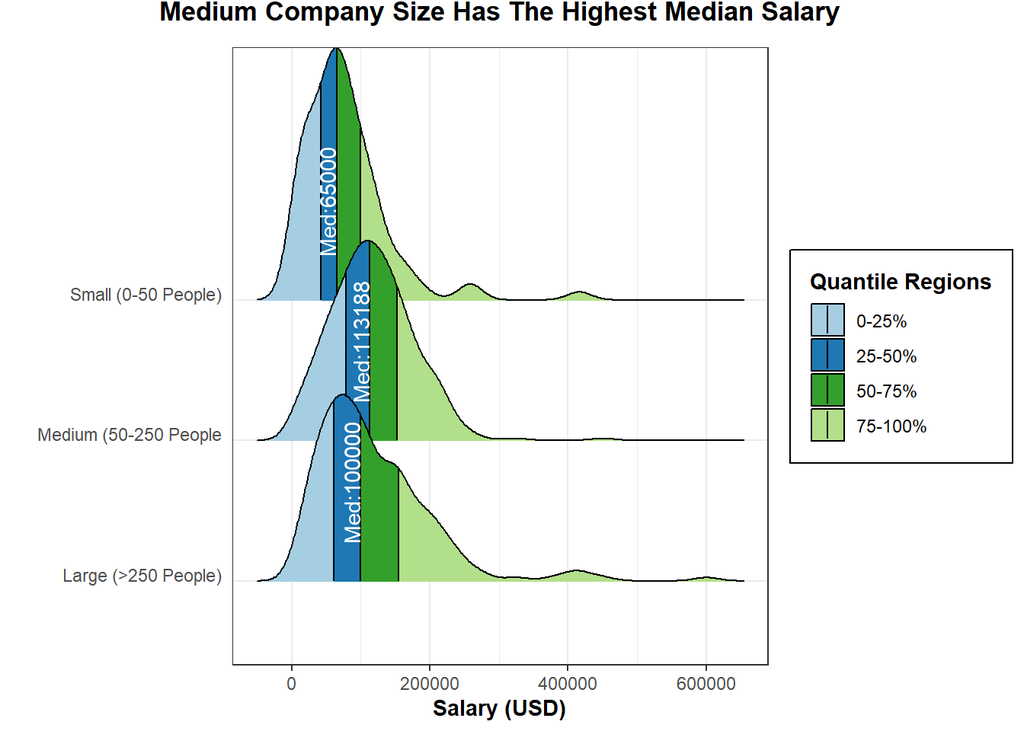

```r
options(scipen=10000)
ds_median_data <- ds_salary_data %>%
  mutate(cp_size = ifelse(company_size == "S", "Small (0-50 People)",ifelse(company_size == "M", "Medium (50-250 People", "Large (>250 People)"))) %>%
  group_by(cp_size) %>%
  drop_na(salary_in_usd, cp_size) %>%
  summarise(salary_in_usd=median(salary_in_usd))

write.csv(ds_median_data, file = "output/ds_median_data.csv")

company_size_data <- ds_salary_data %>%
  mutate(cp_size = ifelse(company_size == "S", "Small (0-50 People)",ifelse(company_size == "M", "Medium (50-250 People", "Large (>250 People)")))

plot3 <- company_size_data %>%
  ggplot(aes(x=salary_in_usd, y=cp_size)) +
  stat_density_ridges(aes(fill = factor(after_stat(quantile))), geom = "density_ridges_gradient", calc_ecdf = TRUE, quantiles = 4, quantile_lines = TRUE) +
  geom_text(data=ds_median_data, aes(label=paste0("Med:",sprintf("%1.0f", salary_in_usd))), position=position_nudge(x=-14000, y=0.7), colour="white", angle = 90) +
  theme_bw() +
  scale_fill_manual(labels = c("0-25%", "25-50%", "50-75%", "75-100%"), values = c("#a6cee3","#1f78b4","#33a02c","#b2df8a")) +
  labs(
    title = "Medium Company Size Has The Highest Median Salary",
    y = "",
    x = "Salary (USD)",
    fill = "Quantile Regions"
  ) +
  theme(
    plot.title = element_text(hjust = 0.5, face = "bold", vjust = 3),
    axis.text.y = element_text(vjust = 0),
    axis.title = element_text(face = "bold"),
    legend.title = element_text(face = "bold"),
    legend.background = element_rect(colour = "black"),
    legend.margin = margin(10,10,10,10),
    axis.ticks.y=element_blank()
  )

blind_colour_plot3 <- cvd_grid(plot3)

ggsave("figs/plot2_colourblind_test.png", plot = blind_colour_plot3, width = 20, height = 20)

ggsave("figs/plot2.png", plot = plot3)

plot3
```

This plot was created by using the data science salary data provided by Kaggle (Bhatia, 2022). Data wrangling methods were used to find the median for each of these categories, in which I used Tidyverse (Wickham et al., 2019). Then a plot was created using ggplot2 with salary on the x-axis and company sizes on the y-axis (Wickham, 2016). The plot that was used is a stat density ridges plot which comes from the ggridges package (Wilke, 2022). Then I used text to display the median on the plot, the command for this came from the standard ggplot2 package (Wickham, 2016). There are 4 quantile zones on this plot, where each zone contains 25 percent of the data. The color was manually chosen using RColorBrewer, specifically chosen to accommodate colourblind people (Neuwirth, 2022). The theme and the labels were changed to improve the reader’s viewability. The final plot was designed to target current data science employee’s/workers, which was why I decided to use a density ridge plot because people in data science should easily understand how these plots function. Not only that, but this plot also allows you to easily compare distributions which is essential in this case. This plot was designed to show how a medium sized company (50-250 workers) was a better overall place to work due to a better salary. We can see this by the distribution shapes; small and large companies have positively skewed distributions while the distribution for a medium size company looks more normal. Just by checking out this plot you notice that a medium size company would be the best company to find jobs in because you would have a higher chance to be paid more than other company sizes. So if you’re already working in a small or large company, the best choice would be to try and find a job with a medium sized company if you’re looking for a higher salary. This is normally true unless your current job pays more than a medium size job could due to the other distributions being positively skewed, then moving would cause a loss in salary. I also changed some names in the plot to allow for easier understanding of the data, for example I explicitly defined what each company size stands for in the plot. In addition, I wanted to be as accessible as possible so I used colorblindr to check how different types of colour blind people could easily see and understand the plot (McWhite & Wilke, 2023). After thoroughly testing the colour palette I finalized the plot and it is included above.

### Plot 3:

#### How does location correlate with someone’s salary? Does remote work correlate with it also?

[figure not shown]

[figure not shown]

```r
options(scipen=10000)

com_location_counts <- ds_salary_data %>%
  count(company_location) %>%
  arrange(desc(n)) %>%
  filter(n > 15)

write.csv(com_location_counts, file = "output/com_Location_counts.csv")

used_data_plot3 <- ds_salary_data %>%
  filter(com_location_counts$company_location == company_location)  %>%
  mutate(cp_loc = ifelse(company_location == "US", "United States",ifelse(company_location == "CA", "Canada", ifelse(company_location == "GB", "United Kingdom", ifelse(company_location == "IN", "India", "Germany"))))) %>%
  mutate(remote = ifelse(remote_ratio == 0, "less than 20% remote workers", ifelse(remote_ratio == 50, "greater than 20% but less than 80% remote workers", "greater than 80% remote workers")))

write.csv(used_data_plot3, file = "output/used_data_plot3.csv")

plot4 <-  used_data_plot3 %>%
    ggplot(aes(x = fct_rev(fct_infreq(cp_loc)))) +
    geom_bar(colour = "black", fill = "lightgrey") +
  coord_flip()+
  theme_bw() +
  labs(
    title = "Countries Above The 15 Job Threshold",
    y = "Number of Salaries Paid",
    x = ""
  ) +
  theme(
    axis.text = element_text(size = 20),
    plot.title = element_text(hjust = 0.5, face = "bold", vjust = 3, size = 20),
    axis.text.y = element_text(vjust = 0),
    axis.title = element_text(face = "bold", size = 15),
    plot.margin = margin(25,25,25,25),
  ) +
  scale_y_continuous(expand = c(0,0), limits = c(0,70))

ggsave("figs/plot3_1.png", plot = plot4)


med_us_data <- used_data_plot3 %>%
  filter(cp_loc == "United States") %>%
  group_by(remote) %>%
  summarise(sal_med = median(salary_in_usd), sd = sd(salary_in_usd), len = length(salary_in_usd)) %>%
  mutate(se = sd / sqrt(len)) %>%
  mutate(CI99 = 2.576*se) %>%
  mutate(y_loc = runif(3, 0.000002, 0.000007))

write.csv(med_us_data, file = "output/med_us_data.csv")

plot5 <- used_data_plot3 %>%
  filter(cp_loc == "United States") %>%
  ggplot(aes(x = salary_in_usd)) +
  geom_density(aes(colour = fct_relevel(remote, "less than 20% remote workers", "greater than 20% but less than 80% remote workers", "greater than 80% remote workers")), fill = "lightgrey", stat = "density", linewidth = 1.5) +
  theme_bw() +
  labs(
    title = "Differences in Salary When it Comes to Remote Work in The United States",
    y = "Density of Salaries Paid",
    x = "Salary (USD)",
    colour = "Remote Work",
    caption = "The median is shown by the same coloured line in each distribution"
  ) +
  scale_colour_OkabeIto() +
  geom_vline(data=med_us_data, aes(xintercept=sal_med, colour= fct_relevel(remote, "less than 20% remote workers", "greater than 20% but less than 80% remote workers", "greater than 80% remote workers")),
             linetype="dashed", size=1) +
  geom_text(data = med_us_data, aes(label = sal_med, y=y_loc, x=sal_med, colour = fct_relevel(remote, "less than 20% remote workers", "greater than 20% but less than 80% remote workers", "greater than 80% remote workers")), size = 5) +
  theme(
    plot.title = element_text(hjust = 0.5, face = "bold", vjust = 3),
    axis.text.y = element_text(vjust = 0),
    axis.title = element_text(face = "bold"),
    legend.title = element_text(face = "bold"),
    legend.background = element_rect(colour = "black"),
    legend.margin = margin(10,10,10,10),
    plot.margin = margin(25,25,25,25),
    plot.caption = element_text(hjust = 0.5, face = "bold", vjust = 3)
  )

median_country_data <- used_data_plot3 %>%
  group_by(cp_loc) %>%
  summarize(salary_in_usd_median = median(salary_in_usd), sd = sd(salary_in_usd), len = length(salary_in_usd)) %>%
  mutate(se = sd / sqrt(len)) %>%
  mutate(CI99 = 2.576*se)

write.csv(median_country_data, file = "output/median_country_data.csv")

plot6 <- used_data_plot3 %>%
  ggplot(aes(x = fct_relevel(cp_loc, "Germany", "Canada", "India", "United Kingdom", "United States"), y = salary_in_usd)) +
  geom_violin(fill = "lightgrey") +
  stat_boxplot(geom = "errorbar", linewidth = 1, width = 0.2) +
  geom_boxplot(colour = "black", width = 0.07, linewidth = 0.5) +
  geom_boxplot(data = median_country_data, aes(x = cp_loc, y = salary_in_usd_median), width = 0.2) +
  coord_flip() +
  theme_bw() +
  labs(
    title = "Differences in Salary When it Comes to Company Location",
    y = "Salary (USD)",
    x = ""
  ) +
  scale_fill_discrete_qualitative(palette = "Dark3") +
  theme(
    axis.text = element_text(size = 20),
    plot.title = element_text(hjust = 0.5, face = "bold", vjust = 3, size = 20),
    axis.text.y = element_text(vjust = 0),
    axis.title = element_text(face = "bold", size = 15),
    plot.margin = margin(25,25,25,25)
  )

ggsave("figs/plot3_2.png", plot = plot6)

anim <- plot5 + transition_states(fct_relevel(remote, "less than 20% remote workers", "greater than 20% but less than 80% remote workers", "greater than 80% remote workers"), transition_length = 2, state_length = 1) +
             enter_fade() +
             exit_fade() +
             shadow_trail(fill = "white", size = 0.75, past = FALSE, future = TRUE) +
             ggtitle("Differences in Salary When it Comes to Remote Work in The United States" , subtitle = "Now showing companies with {closest_state}")

#animate(anim, duration = 8, fps = 30, width = 800, height = 400, renderer = gifski_renderer())
#anim_save("figs/plot3_3v2.gif")

plot7 <- plot4 + plot6

plot7
```

### Reflection

First off, I would like to thank R studio for creating an easy interactive R programming environment (R Core Team, 2022). Also, the package here was used to create a more function tidy project (Müller, 2020). Finally the package readr was used to keep this project clean (Wickham, Hester, & Bryan, 2022). Any other package used indirectly will be cited below. Moving on to the main chunk of the reflection, I do believe that my plots answer the questions I created. The first question was not only answered but expanded upon, not only looking at entry-level salaries for students coming out of university but also looking at possible future earnings. This type of visualization was appropriate for students coming out of university, but may not be appropriate for people already in the industry. For my second question, I wanted to show how varying company sizes correlates with salary. I believe I did this pretty well using a density ridge plot which might be harder to understand than other plots because it is not as well known. The plot is directed to data scientists who would already know and/or have used this plot, making this plot an effective way at displaying data. Finally, for my last question I needed to simplify the plots to make them easier for the general public to understand. Sure the dataset is about data science jobs, but the factors discussed in this question effect multiple different career fields. Therefore, I wanted to make the plots accessible and understandable to the general public without overwhelming the reader. The plot is read left to right and top to bottom, each part of the plot tells a different story, which when put together answers the general question. Also, the dataset used for this project is very reliable - it was properly sourced and information about where the data was collected from was revealed to users. In addition, each variable in the dataset was properly explained with no interpolation needed. One thing I would have loved to improve is the animated part of the third plot. I would have loved to make a clean, animated density plot which showed uncertainty for each of the medians but sadly this was too difficult to create in the time I had, mostly due to the fact that I had to make it as readable as possible. Also, I believe median was the best choice to measure central tendency because nearly all of this dataset is skewed and mean tends to be greatly effected by skewness. Overall, I enjoyed creating this project and learning more about possible future careers for myself in this field.

Work Cited

Bhatia, R. (2022). *Data science job salaries*. https://www.kaggle.com/datasets/ruchi798/data-science-job-salaries

Henry, L., & Wickham, H. (2022). *Purrr: Functional programming tools*. https://CRAN.R-project.org/package=purrr

McWhite, C. D., & Wilke, C. O. (2023). *Colorblindr: Simulate colorblindness in r figures*. https://github.com/clauswilke/colorblindr

Müller, K. (2020). *Here: A simpler way to find your files*. https://CRAN.R-project.org/package=here

Müller, K., & Wickham, H. (2022). *Tibble: Simple data frames*. https://CRAN.R-project.org/package=tibble

Neuwirth, E. (2022). *RColorBrewer: ColorBrewer palettes*. https://CRAN.R-project.org/package=RColorBrewer

Ooms, J. (2022). *Gifski: Highest quality GIF encoder*. https://CRAN.R-project.org/package=gifski

Pedersen, T. L. (2022a). *Patchwork: The composer of plots*. https://CRAN.R-project.org/package=patchwork

Pedersen, T. L. (2022b). *Transformr: Polygon and path transformations*. https://CRAN.R-project.org/package=transformr

Pedersen, T. L., & Robinson, D. (2022). *Gganimate: A grammar of animated graphics*. https://CRAN.R-project.org/package=gganimate

R Core Team. (2022). *R: A language and environment for statistical computing*. R Foundation for Statistical Computing. https://www.R-project.org/

Tiedemann, F. (2022). *Gghalves: Compose half-half plots using your favourite geoms*. https://CRAN.R-project.org/package=gghalves

Wickham, H. (2016). *ggplot2: Elegant graphics for data analysis*. Springer-Verlag New York. https://ggplot2.tidyverse.org

Wickham, H. (2022a). *Forcats: Tools for working with categorical variables (factors)*. https://CRAN.R-project.org/package=forcats

Wickham, H. (2022b). *Stringr: Simple, consistent wrappers for common string operations*. https://CRAN.R-project.org/package=stringr

Wickham, H., Averick, M., Bryan, J., Chang, W., McGowan, L. D., François, R., Grolemund, G., Hayes, A., Henry, L., Hester, J., Kuhn, M., Pedersen, T. L., Miller, E., Bache, S. M., Müller, K., Ooms, J., Robinson, D., Seidel, D. P., Spinu, V., … Yutani, H. (2019). Welcome to the tidyverse. *Journal of Open Source Software*, *4*(43), 1686. https://doi.org/10.21105/joss.01686

Wickham, H., Bryan, J., & Barrett, M. (2022). *Usethis: Automate package and project setup*. https://CRAN.R-project.org/package=usethis

Wickham, H., François, R., Henry, L., Müller, K., & Vaughan, D. (2023). *Dplyr: A grammar of data manipulation*. https://CRAN.R-project.org/package=dplyr

Wickham, H., & Girlich, M. (2022). *Tidyr: Tidy messy data*. https://CRAN.R-project.org/package=tidyr

Wickham, H., Hester, J., & Bryan, J. (2022). *Readr: Read rectangular text data*. https://CRAN.R-project.org/package=readr

Wickham, H., Hester, J., Chang, W., & Bryan, J. (2022). *Devtools: Tools to make developing r packages easier*. https://CRAN.R-project.org/package=devtools

Wilke, C. O. (2022). *Ggridges: Ridgeline plots in ’ggplot2’*. https://CRAN.R-project.org/package=ggridges

Zeileis, A., Hornik, K., & Murrell, P. (2009). Escaping RGBland: Selecting colors for statistical graphics. *Computational Statistics & Data Analysis*, *53*(9), 3259–3270. https://doi.org/10.1016/j.csda.2008.11.033